# BTEP-R/RStudio-Intro

## What is tribble

- transposed tibble, tribble()
- small data in readable form
- column headings are shown as formulas ( ie ~ )
- nice format
- no need to explicitely use head command (Ex. head cars)

```r
tribble(
  ~x, ~y, ~z,
  #--|--|----
  "Male", 187, 210,
  "Female", 190, 150
)
```

```
## # A tibble: 2 × 3
##        x     y     z
##    <chr> <dbl> <dbl>
## 1   Male   187   210
## 2 Female   190   150
```

Let us create a little bit complicated tibble note that lubridate gives the current time

```r
t2 <- tibble(
  a = lubridate::now() + runif(1e3) * 86400,
  b = lubridate::today() + runif(1e3) * 30,
  c = 1:1e3,
  d = runif(1e3),
  e = sample(letters, 1e3, replace = TRUE)
)
```

```r
t2
```

```
## # A tibble: 1,000 × 5
##                      a          b     c         d     e
##                 <dttm>     <date> <int>     <dbl> <chr>
## 1  2017-04-06 02:00:47 2017-04-21     1 0.7166582     h
## 2  2017-04-05 16:46:24 2017-04-27     2 0.3944225     u
## 3  2017-04-06 13:20:22 2017-04-23     3 0.9615016     e
## 4  2017-04-06 13:22:10 2017-04-05     4 0.6597890     e
## 5  2017-04-06 01:26:17 2017-04-15     5 0.8667229     s
## 6  2017-04-06 06:11:42 2017-04-10     6 0.1540270     z
## 7  2017-04-06 02:10:32 2017-05-03     7 0.1362295     w
## 8  2017-04-06 14:14:48 2017-04-17     8 0.2447185     o
## 9  2017-04-06 09:25:14 2017-04-12     9 0.8235809     d
## 10 2017-04-06 13:46:37 2017-04-10    10 0.9099182     o
## # ... with 990 more rows
```

You can change the defaults of tibble display with options.

```r
options(tibble.print_max = 10, tibble.print_min = 6)
t2
```

```
## # A tibble: 1,000 × 5
##                     a          b     c         d     e
##                <dttm>     <date> <int>     <dbl> <chr>
## 1 2017-04-06 02:00:47 2017-04-21     1 0.7166582     h
## 2 2017-04-05 16:46:24 2017-04-27     2 0.3944225     u
## 3 2017-04-06 13:20:22 2017-04-23     3 0.9615016     e
## 4 2017-04-06 13:22:10 2017-04-05     4 0.6597890     e
## 5 2017-04-06 01:26:17 2017-04-15     5 0.8667229     s
## 6 2017-04-06 06:11:42 2017-04-10     6 0.1540270     z
## # ... with 994 more rows
```

You can also use the following tibble option to show all columns

```r
options(tibble.width = Inf)
# more options available at
package?tibble
```

How to extract the columns or rows of tibble?

```r
head(t2$a)
```

```
## [1] "2017-04-06 02:00:47 EDT" "2017-04-05 16:46:24 EDT"
## [3] "2017-04-06 13:20:22 EDT" "2017-04-06 13:22:10 EDT"
## [5] "2017-04-06 01:26:17 EDT" "2017-04-06 06:11:42 EDT"
```

```r
has_name(t2, "b")
```

```
## [1] TRUE
```

```r
getOption("tibble.max_extra_cols")
```

how to add a row of a tibble in a specific place?

original t2

```r
t2
```

```
## # A tibble: 1,000 × 5
##                     a          b     c         d     e
##                <dttm>     <date> <int>     <dbl> <chr>
## 1 2017-04-06 02:00:47 2017-04-21     1 0.7166582     h
## 2 2017-04-05 16:46:24 2017-04-27     2 0.3944225     u
## 3 2017-04-06 13:20:22 2017-04-23     3 0.9615016     e
## 4 2017-04-06 13:22:10 2017-04-05     4 0.6597890     e
## 5 2017-04-06 01:26:17 2017-04-15     5 0.8667229     s
## 6 2017-04-06 06:11:42 2017-04-10     6 0.1540270     z
## # ... with 994 more rows
```

```r
    aa = lubridate::today()
    bb = lubridate::now()
    cc = 1:1
    dd = runif(1)
    ee = sample(letters, 1, replace = TRUE)
    print(aa); print(bb); print(cc); print(dd); print(ee)
```

```
## [1] "2017-04-05"
```

```
## [1] "2017-04-05 14:15:11 EDT"
```

```
## [1] 1
```

```
## [1] 0.3656515
```

```
## [1] "l"
```

```r
t2 %>%
  add_row(
    a = aa,
    b = bb,
    c = cc,
    d = dd,
    e = ee, .before = 2  # note the dot in ".before = 2"
)
```

```
## # A tibble: 1,001 × 5
##                     a          b     c         d     e
##                <dttm>     <date> <int>     <dbl> <chr>
## 1 2017-04-06 02:00:47 2017-04-21     1 0.7166582     h
## 2 2017-04-04 20:00:00 2017-04-05     1 0.3656515     l
## 3 2017-04-05 16:46:24 2017-04-27     2 0.3944225     u
## 4 2017-04-06 13:20:22 2017-04-23     3 0.9615016     e
## 5 2017-04-06 13:22:10 2017-04-05     4 0.6597890     e
## 6 2017-04-06 01:26:17 2017-04-15     5 0.8667229     s
## # ... with 995 more rows
```

After the change

```r
t2
```

```
## # A tibble: 1,000 × 5
##                     a          b     c         d     e
##                <dttm>     <date> <int>     <dbl> <chr>
## 1 2017-04-06 02:00:47 2017-04-21     1 0.7166582     h
## 2 2017-04-05 16:46:24 2017-04-27     2 0.3944225     u
## 3 2017-04-06 13:20:22 2017-04-23     3 0.9615016     e
## 4 2017-04-06 13:22:10 2017-04-05     4 0.6597890     e
## 5 2017-04-06 01:26:17 2017-04-15     5 0.8667229     s
## 6 2017-04-06 06:11:42 2017-04-10     6 0.1540270     z
## # ... with 994 more rows
```

## Subsetting

- $ by name

```r
df <- tibble(
  x = runif(5),
  y = rnorm(5)
)

df$x
```

```
## [1] 0.76475692 0.01135579 0.09665402 0.49061187 0.03154310
```

```r
df[[1]]
```

```
## [1] 0.76475692 0.01135579 0.09665402 0.49061187 0.03154310
```

Can you use Tibble in a pipeline?

```r
df %>% .$x
```

```
## [1] 0.76475692 0.01135579 0.09665402 0.49061187 0.03154310
```

```r
df %>% .[["y"]]
```

```
## [1]  0.58702641 -3.29476045 -0.05227822  0.22150215 -0.63593082
```

What happens if tibble doesnt work with a package? Transform Tibble back to a data.frame using the following command:

```r
as.data.frame(df)
```

```
##            x           y
## 1 0.76475692  0.58702641
## 2 0.01135579 -3.29476045
## 3 0.09665402 -0.05227822
## 4 0.49061187  0.22150215
## 5 0.03154310 -0.63593082
```

### Tibble Exercise-2

Create a new tibble with the following information: name, age, height, weight, smoker (T or F), Male (True or Fale) compare the tibble with the R data_frame

### Tibble Exercise-3

convert iris data set (given to us in data.frame ) to tibble data_frame

### Tibble Exercise-4

How can you tell whether the object is a Tibble or not?

### Tibble Exercise-5 (based on Hadley’s tutorial)

Partial matching is a big issue with data.frame. df <- data.frame(abc = 1, xyz = “a”) df$x df[, “xyz”]

### Final R-basic exercise

The datset that we will be using for this section comes from the  
National Electronic Injury Surveillance System (NEISS) https://www.cpsc.gov/research--statistics/neiss-injury-data Here is a short description of the data file from the NEISS.

*“Each record (case) is separated by a carriage return/line feed, and the fields (parameters and narrative) are separated by a tab character, which you can specify as the delimiter when importing into a spreadsheet or database.”*

Before you read in the data, please take a look at the following two files: **NEISS_SAS_formats.txt** and **NEISS_SAS_variance.txt** These two files will act as the codebook for the data.

Read the data file, **nss15.tsv** file from the sub-folder/directory, **Data** and call the data as **nss15** variable.

**Hint:** Use the File –> Import –> Data DataSet option to read the file. To remind the data is in a tab-separated format.

**Hint:** Watch out for the Data Type choices that are suggested to you and choose the appropriate ones

**Hint:** Please watch out for any warnings or issues while R/Rstudio is reading the files. If you spot any errors, think of how to fix it. After fixing the problems (if any), go back and read the file.

Answer the following questions.

- How many cases are reported in this dataset?
- How many covariates this dataset has?
- Access CPSC Case # 150620565 and report the following things: What is the age of the patient? What is the Race, weight, Stratum, Sex, Race and Diagnosis
- How many are more than 100 years old?
- How many cases were taken to **Children’s Hospital**? From the reported cases, get the CPSC case number and age for the 20th entry.

### Ignore from here to the end for the moment

## Hands-on exercise using Wisconsin Breast Cancer dataset

Now, let us read a slightly complicated Breast Cancer dataset. First let us use the import data set drop-down option

[figure not shown]

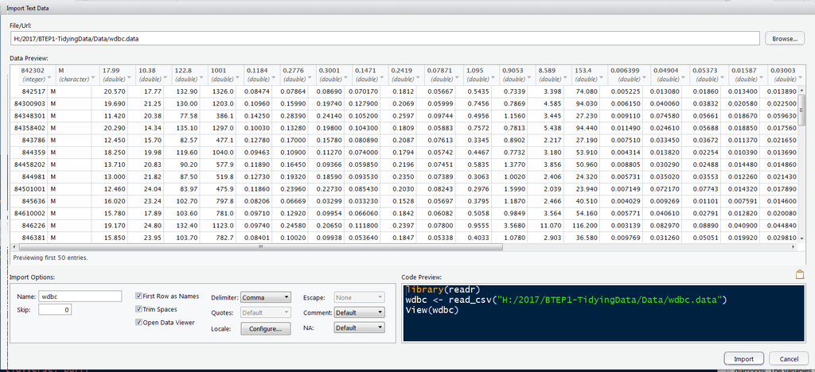

```r
#wdbc <- read_csv("C:/Users/Ravi/Desktop/BTEP/Data/wdbc.data", col_names = FALSE)

wdbc <- read_csv("Data/wdbc.data", col_names = FALSE)
#wdbctry2 <- read_csv("C:/Users/Ravi/Desktop/BTEP/Data/wdbc.data", header = FALSE)
names(wdbc)
```

```
##  [1] "X1"  "X2"  "X3"  "X4"  "X5"  "X6"  "X7"  "X8"  "X9"  "X10" "X11"
## [12] "X12" "X13" "X14" "X15" "X16" "X17" "X18" "X19" "X20" "X21" "X22"
## [23] "X23" "X24" "X25" "X26" "X27" "X28" "X29" "X30" "X31" "X32"
```

Let us add column names

```r
cnames <- c("ID", "Diagnosis",
            "radius", "Texture", "Perimeter", "area",
            "smoothness", "compactness", "concavity", "concave_points",
            "symmetry","fractaldim",
            "radiusSE", "TextureSE", "PerimeterSE", "areaSE",
            "smoothnessSE", "compactnessSE", "concavitySE", "concave_pointsSE",
            "symmetrySE","fractaldimSE",
            "radiusW", "TextureW", "PerimeterW", "areaW",
            "smoothnessW", "compactnessW", "concavityW", "concave_pointsW",
            "symmetryW","fractaldimW")

names(wdbc) <- cnames
```

Let us find out how many samples we have in the dataset?

```r
nrow(wdbc)
```

```
## [1] 569
```

```r
ncol(wdbc)
```

```
## [1] 32
```

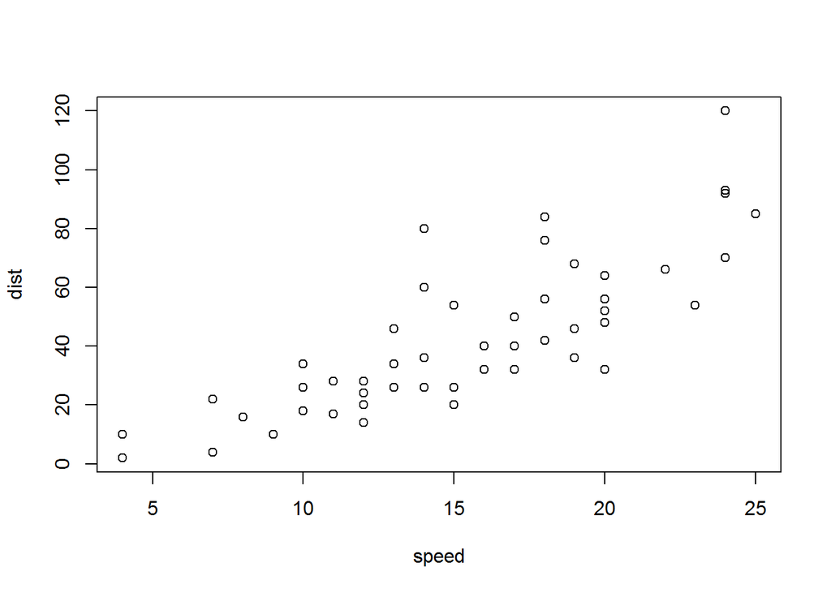

cars

```r
with(cars, plot(speed,dist))
```